# nlraa: Models and Functions for Mixed Models

Fernando Miguez

2023-12-02

# Intro

The puspose of this note is to make a connection between R functions and the mathematical notation of linear and (non)linear mixed models. One goal is to produce a table that maps R functions with notation for these models.

This document is a work in progress.

## Linear Model

A linear model can be expressed as

$$y = X \beta + \epsilon$$

Typically, we assume that the errors are normally distributed, independent and they have constant variance.

$$\epsilon \sim N(0, \sigma^2)$$

Note: The covariance of the errors $Cov(\mathbf{\epsilon})$ where $\mathbf{\epsilon}$ is an $n \times 1$ vector is $\sigma^2 \mathbf{I}_n$.

In R we can fit the following model

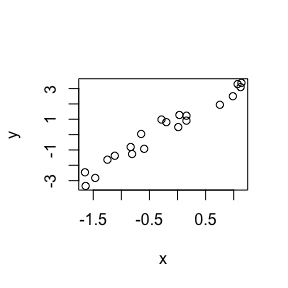

```r
x <- rnorm(20)
y <- 1 + 2 * x + rnorm(20, sd = 0.5)
plot(x, y)
```

```r
fit <- lm(y ~ x)
```

In order to extract the estimate for $\beta$, this is $\hat{\beta}$, we can use the function *coef*. In order to extract the estiamte for $\sigma$ (again, strictly $\hat{\sigma}$), we can use the function *sigma*. In order to extract the covariance of $\hat{\beta}$, this is $Cov(\hat{\beta})$, we can use the function *vcov*.

The covariance for $\hat{\beta}$ is defined as

$$Cov(\hat{\beta}) = \hat{\sigma}^2 (\mathbf{X'X})^{-1}$$

Obtaining this matrix is important for simulation as it provides information on the variances for the parameters in the model as well as the covariances.

```r
## Print beta hat
coef(fit)
```

```
## (Intercept)           x
##   0.8059534   2.1388860
```

```r
## Print sigma
sigma(fit)
```

```
## [1] 0.4212005
```

```r
## Print the covariance matrix of beta hat
vcov(fit)
```

```
##             (Intercept)           x
## (Intercept) 0.009551574 0.002697391
## x           0.002697391 0.010682887
```

There are other functions in R which are also useful. The function *fitted* extracts the fitted values or $\hat{y} = \mathbf{X}\hat{\beta}$, *model.matrix* extracts $\mathbf{X}$ and *residuals* extracts $\hat{e}$ (or *resid*).

In addition, in the nlraa package I have the function ‘var_cov’ which extracts the complete variance of the residuals. In this case it is a simple diagonal matrix multiplied by $\hat{\sigma}^2$.

```r
## Extract the variance covariance of the residuals (which is also of the response)
lm.vc <- var_cov(fit)
## Print just the first 5 observations
round(lm.vc[1:5,1:5],2)
```

```
##      [,1] [,2] [,3] [,4] [,5]
## [1,] 0.18 0.00 0.00 0.00 0.00
## [2,] 0.00 0.18 0.00 0.00 0.00
## [3,] 0.00 0.00 0.18 0.00 0.00
## [4,] 0.00 0.00 0.00 0.18 0.00
## [5,] 0.00 0.00 0.00 0.00 0.18
```

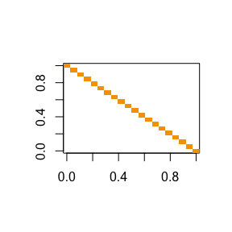

```r
## Visualize the matrix. This is a 20 x 20 matrix.
## It is easier to visualize in the log-scale
## Note: log(0) becomes -Inf, but not shown here
image(log(lm.vc[,ncol(lm.vc):1]))
```

In the previous image, each orange square represents the estimate of the residual variance ($\sigma^2$) and there are 20 squares because there are 20 observations.

It might seem silly for a model such as this one to extract a matrix which is simlpy a diagonal identity matrix multiplied by the scalar $\hat{\sigma}^2$, but this will become more clear as we move into more complex models.

So far,

| r.function | beta | cov.beta | sigma | X | y.hat | e | cov.e |
| --- | --- | --- | --- | --- | --- | --- | --- |
| lm | coef | vcov | sigma | model.matrix | fitted | residuals | var_cov |

## Generalized least squares (gls)

Note: The models that can be fitted using *gls* should not be confused with the ones fitted using *glm*, which are generalized linear models.

The function *gls* in the *nlme* package fits linear models, but in which the covariance matrix of the residuals (also called errors) is more flexible.

The model is still

$$y = X \beta + \epsilon$$

But now the errors have a more flexible covariance structure.

$$\epsilon \sim N(0, \Sigma)$$

How do we extract $\Sigma$ from a fitted model?

We will again use the function *var_cov* (there is a function in nlme called *getVarCov*, but there are many cases which it does not handle).

For the next example I will use the ChickWeight dataset.

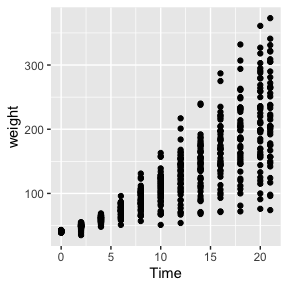

```r
## ChickWeight example
data(ChickWeight)
ggplot(data = ChickWeight, aes(Time, weight)) + geom_point()
```

Clearly, the variance increases as the weight increases and it would be a good approach to consider this in the modeling process. The code below fits the variance of the residuals (or the response) as a function of the fitted values. We could choose and evaluate different variance functions and determine which one is better, but for the purpose of illustrating the connection between R functions and mathematical notation this is enough.

```r
## One possible model is
fit.gls <- gls(weight ~ Time, data = ChickWeight,
               weights = varPower())
fit.gls.vc <- var_cov(fit.gls)
## Note: the function getVarCov fails for this object
## Visualize the first few observations
fit.gls.vc[1:10,1:10]
```

```
##           [,1]     [,2]     [,3]     [,4]     [,5]     [,6]     [,7]     [,8]
##  [1,] 3.530572  0.00000  0.00000   0.0000   0.0000   0.0000    0.000    0.000
##  [2,] 0.000000 15.12026  0.00000   0.0000   0.0000   0.0000    0.000    0.000
##  [3,] 0.000000  0.00000 47.53714   0.0000   0.0000   0.0000    0.000    0.000
##  [4,] 0.000000  0.00000  0.00000 122.3036   0.0000   0.0000    0.000    0.000
##  [5,] 0.000000  0.00000  0.00000   0.0000 273.3773   0.0000    0.000    0.000
##  [6,] 0.000000  0.00000  0.00000   0.0000   0.0000 550.6203    0.000    0.000
##  [7,] 0.000000  0.00000  0.00000   0.0000   0.0000   0.0000 1023.508    0.000
##  [8,] 0.000000  0.00000  0.00000   0.0000   0.0000   0.0000    0.000 1785.058
##  [9,] 0.000000  0.00000  0.00000   0.0000   0.0000   0.0000    0.000    0.000
## [10,] 0.000000  0.00000  0.00000   0.0000   0.0000   0.0000    0.000    0.000
##           [,9]    [,10]
##  [1,]    0.000    0.000
##  [2,]    0.000    0.000
##  [3,]    0.000    0.000
##  [4,]    0.000    0.000
##  [5,]    0.000    0.000
##  [6,]    0.000    0.000
##  [7,]    0.000    0.000
##  [8,]    0.000    0.000
##  [9,] 2955.968    0.000
## [10,]    0.000 4688.938
```

```r
## Store for visualization
## only the first 12 observations
vc2 <- fit.gls.vc[1:12,1:12]
round(vc2,0)
```

```
##       [,1] [,2] [,3] [,4] [,5] [,6] [,7] [,8] [,9] [,10] [,11] [,12]
##  [1,]    4    0    0    0    0    0    0    0    0     0     0     0
##  [2,]    0   15    0    0    0    0    0    0    0     0     0     0
##  [3,]    0    0   48    0    0    0    0    0    0     0     0     0
##  [4,]    0    0    0  122    0    0    0    0    0     0     0     0
##  [5,]    0    0    0    0  273    0    0    0    0     0     0     0
##  [6,]    0    0    0    0    0  551    0    0    0     0     0     0
##  [7,]    0    0    0    0    0    0 1024    0    0     0     0     0
##  [8,]    0    0    0    0    0    0    0 1785    0     0     0     0
##  [9,]    0    0    0    0    0    0    0    0 2956     0     0     0
## [10,]    0    0    0    0    0    0    0    0    0  4689     0     0
## [11,]    0    0    0    0    0    0    0    0    0     0  7173     0
## [12,]    0    0    0    0    0    0    0    0    0     0     0  8767
```

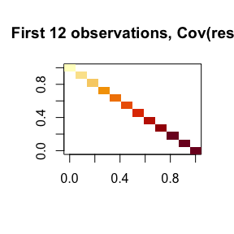

```r
## The variance increases as weight increases
## Visualize the variance-covariance of the errors
## This is only for the first 12 observations
## It is easier to visualize in the log scale
## Note: log(0) becomes -Inf, but not shown here
image(log(vc2[,ncol(vc2):1]),
      main = "First 12 observations, Cov(resid)")
```

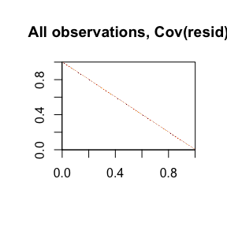

```r
## For all observations
image(log(fit.gls.vc[,ncol(fit.gls.vc):1]),
      main = "All observations, Cov(resid)")
```

Since not only the variance is increasing, but also the data comes from different chick and is thus correlated, we could fit the following model.

```r
## Adding the correlation
fit.gls2 <- gls(weight ~ Time, data = ChickWeight,
                weights = varPower(),
                correlation = corCAR1(form = ~ Time | Chick))
## Extract the variance-covariance of the residuals
## Note: getVarCov fails for this object
fit.gls2.vc <- var_cov(fit.gls2)
## Visualize the first few observations
round(fit.gls2.vc[1:13,1:13],0)
```

```
##       [,1] [,2] [,3] [,4] [,5] [,6] [,7] [,8] [,9] [,10] [,11] [,12] [,13]
##  [1,]   89  129  178  236  302  377  462  555  658   770   890   954     0
##  [2,]  129  194  267  353  452  565  692  832  985  1152  1333  1428     0
##  [3,]  178  267  379  501  642  803  982 1181 1400  1637  1893  2029     0
##  [4,]  236  353  501  684  877 1096 1341 1613 1911  2235  2584  2769     0
##  [5,]  302  452  642  877 1160 1449 1774 2133 2527  2956  3418  3663     0
##  [6,]  377  565  803 1096 1449 1869 2287 2750 3259  3811  4408  4723     0
##  [7,]  462  692  982 1341 1774 2287 2888 3473 4115  4813  5566  5964     0
##  [8,]  555  832 1181 1613 2133 2750 3473 4310 5106  5972  6907  7400     0
##  [9,]  658  985 1400 1911 2527 3259 4115 5106 6241  7300  8443  9046     0
## [10,]  770 1152 1637 2235 2956 3811 4813 5972 7300  8809 10188 10916     0
## [11,]  890 1333 1893 2584 3418 4408 5566 6907 8443 10188 12158 13026     0
## [12,]  954 1428 2029 2769 3663 4723 5964 7400 9046 10916 13026 14177     0
## [13,]    0    0    0    0    0    0    0    0    0     0     0     0    89
```

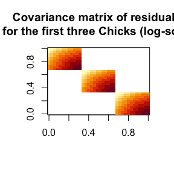

```r
## Visualize the variance-covariance of the errors
## On the log-scale
## Reorder and select
vc2.36 <- fit.gls2.vc[1:36,1:36]
image(log(vc2.36[,ncol(vc2.36):1]),
      main = "Covariance matrix of residuals \n for the first three Chicks (log-scale)")
```

Let’s plot the data, by Chick. this shows that there is a high temporal correlation as we would expect. Chicks which have a higher weight (than others) at given time, tend to still be higher at a later time.

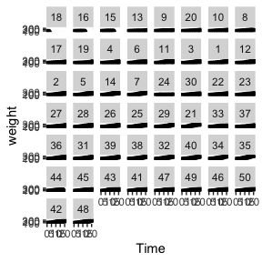

```r
ggplot(data = ChickWeight, aes(x = Time, y = weight)) +
  facet_wrap( ~ Chick) +
  geom_point()
```